# R Notebook

```r
library(MTS)
library(arfima)
library(forecast)
```

Dai grafici sembrano due serie stazionarie CO2 serie risposta GAS serie in input

Anche acf non sono così male

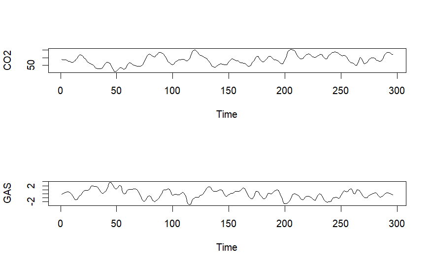

```r
data("SeriesJ")
?arfima

CO2 = SeriesJ$YJ #serie di output
GAS = SeriesJ$XJ #serie di input

par(mfrow=c(2,1))

plot(CO2)
plot(GAS)
```

```r
acf(CO2, 60)
acf(GAS, 60)
```

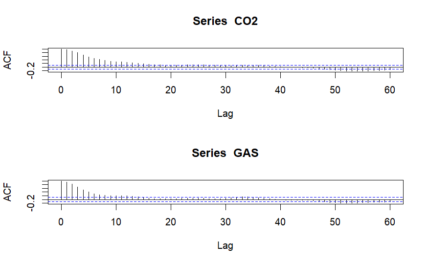

```r
par(mfrow=c(1,1))
```

Dalla ccf non si capisce molto, ma è normale le serie devo no essere ancora sbiancate

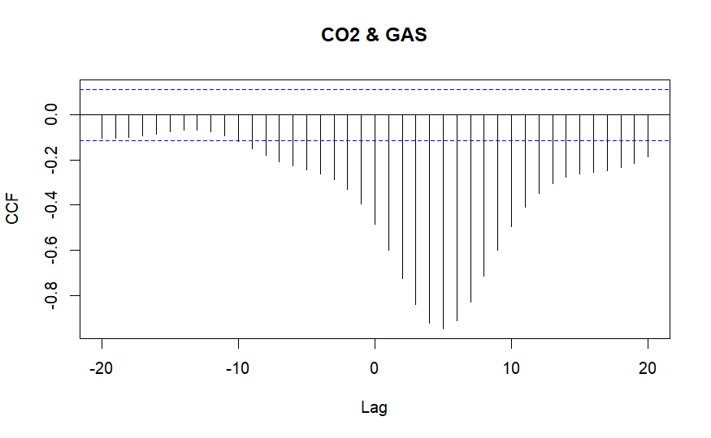

```r
ccf(CO2, GAS, lag.max = 20, ylab = "CCF")
```

Capiamo in modello migliore per xt in modo da sbiancare potrebbe essere AR(3)

```r
par(mfrow=c(2,1))
acf(GAS, 60)
pacf(GAS, 60)
```

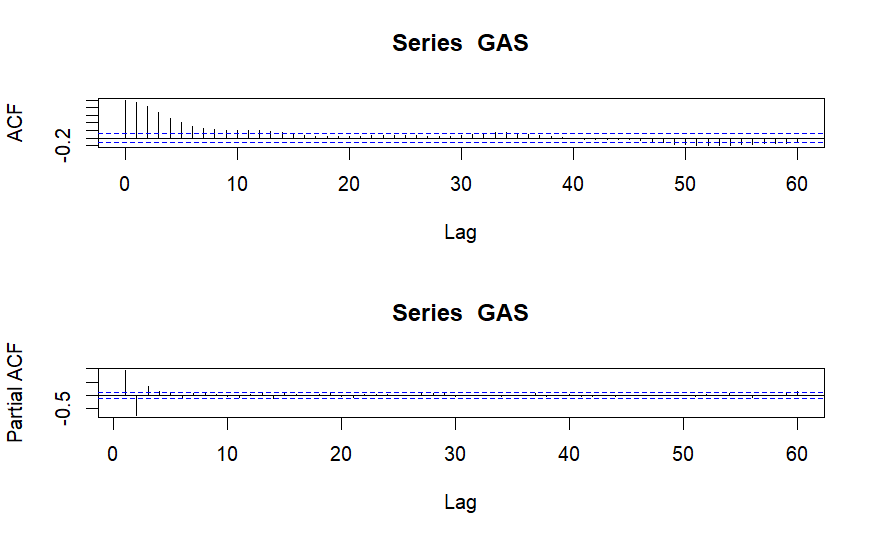

```r
par(mfrow=c(1,1))
```

```r
modx = Arima(GAS, order = c(3, 0, 0))
modx

modx_2 = Arima(GAS, order = c(4, 0, 0))
modx_2
```

[output not shown]

```r
par(mfrow=c(2,1))
acf(modx$residuals, 20)
pacf(modx$residuals, 20)
par(mfrow=c(1,1))
```

[output not shown]

Passo da x ad alpha prendendo i residui del modello che ho scelto in precedenza Applico lo stesso modello a y e passo a beta

Quindi ora non ho più x, y ma alpha, beta

```r
alpha = modx$residuals

mod_filter = Arima(CO2, model = modx) #filtra con lo stesso modello la serie in input
mod_filter

beta = mod_filter$residuals
```

[output not shown]

Ho una cross correlazione negativa tra la serie di output e di input Controllo ccf ed indentifico, ma b = 3, s = 2, r = 1 non sono sicuro Applico comunque un tfm senza tenere conto della modellazione dell’errore Quindi assumo che sia WN anche lui, prob non è così

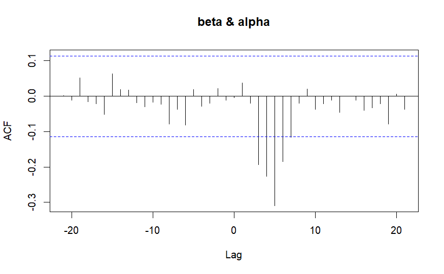

```r
ccf(beta, alpha) #alpha(t) "x" e beta(t+k) "y"
```

```r
#b = 3, s = 2, r = 1 non sono sicuro
tfmod1 = tfm1(CO2, GAS, orderN = c(0, 0, 0), orderX = c(1, 2, 3)) #r, s, b
```

```
Avvertimento: NA/Inf sostituito da valore massimo positivo
```

```
Delay:  3
Transfer function coefficients & s.e.:
in the order: constant, omega, and delta: 1 3 1
        [,1]   [,2]   [,3]   [,4]   [,5]
v    53.3234 -0.563 -0.430 -0.296 0.6012
se.v  0.0489  0.234  0.495  0.395 0.0476
```

```r
ccf(alpha, tfmod1$residuals, main = "alfa & TFM", ylab = "CCF")
```

[output not shown]

Controllo ora i reisdui del modello per capire se hanno effettivamente un comportamento WN No anzi sembrano un AR(3)

Rifaccio il modello modellando anche l’errore applicando un AR(3), ma il terzo coeff phi non è sign allora potrebbe essere un AR(2), ho solo coeff sign

Le acf e pacf dei residui adesso vanno bene

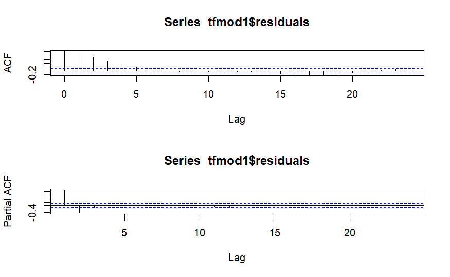

```r
par(mfrow=c(2,1))
acf(tfmod1$residuals)
pacf(tfmod1$residuals)
```

```r
tfmod1_1 = tfm1(CO2, GAS, orderN = c(3, 0, 0), orderX = c(1, 2, 3)) #p,d,q per "errore" & r, s, b per "x"
```

```
Avvertimento: NA/Inf sostituito da valore massimo positivoAvvertimento: NA/Inf sostituito da valore massimo positivo
```

```
Delay:  3
Transfer function coefficients & s.e.:
in the order: constant, omega, and delta: 1 3 1
       [,1]    [,2]   [,3]   [,4]   [,5]
v    53.378 -0.5267 -0.382 -0.519 0.5468
se.v  0.154  0.0744  0.101  0.109 0.0404
ARMA order:
[1] 3 0 0
ARMA coefficients & s.e.:
            [,1]   [,2]   [,3]
coef.arma 1.5569 -0.695 0.0448
se.arma   0.0592  0.102 0.0637
```

```r
tfmod1_1 = tfm1(CO2, GAS, orderN = c(2, 0, 0), orderX = c(1, 2, 3)) #p,d,q per "errore" & r, s, b per "x"
```

```
Avvertimento: NA/Inf sostituito da valore massimo positivo
```

```
Delay:  3
Transfer function coefficients & s.e.:
in the order: constant, omega, and delta: 1 3 1
       [,1]   [,2]   [,3]   [,4]   [,5]
v    53.370 -0.530 -0.380 -0.519 0.5489
se.v  0.142  0.074  0.102  0.109 0.0394
ARMA order:
[1] 2 0 0
ARMA coefficients & s.e.:
            [,1]    [,2]
coef.arma 1.5314 -0.6321
se.arma   0.0472  0.0501
```

```r
acf(tfmod1_1$residuals)
pacf(tfmod1_1$residuals)
```

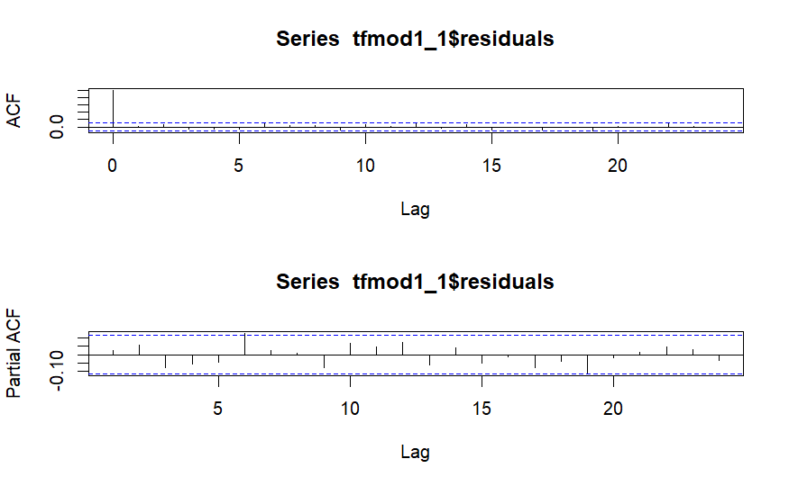

```r
par(mfrow=c(1,1))
```